# Federal Budget Analysis for the 8th Period of 2025

## Dataset

### This dataset was taken directly from the United States government spending website, USAspending.gov. This is publically available data that allows anyone to download the budgets for different agencies within the United States. In this case, the period was marked as FY2025P08 (Fiscal Period 2025, Period 8).

### Intro

#### This project explores how public funds are allocated and spent across U.S. federal agencies using real financial data from USAspending.gov. The goal is to uncover patterns in budgeting, identify potential inefficiencies, and evaluate how different agencies use their allocated funds.

#### Although this project was primarily done to practice SQL within context, this analysis was designed to answer real business questions, similar to the work real business/data analysts might do. Through a series of SQL-based challenges, I examined:

#### Which agencies commit the most funding?

#### Which programs are spending more than they were budgeted?

#### Which accounts are underutilizing their available resources?

#### How efficiently are departments turning allocated budgets into real spending?

#### This data comes from a single submission period but is very in depth with financial records across all major U.S. agencies. The project involved normalized database tables, importing raw CSV files, and writing queries to answer questions about the data.

#### Tools used: PostgreSQL, Excel (for cleaning), pgAdmin, SQL

#### Key skills demonstrated:

#### - Financial data analysis

#### - SQL joins, aggregates, case logic

#### - Performance benchmarking and budget efficiency analysis

## Part 1: Data Importing and Excel Cleanup

### The first step to take is to take the downloaded csv file from the government website and turn it into useable data. The original Excel contains all the columns on one sheet which not only makes it difficult to look at but also costs storage space. Therefore my next step was to normalize the data. Below is the SQL code that demonstrates how I split the initial table into the different sections based on the groups, with agency, function, and account ids created to allow for joining.

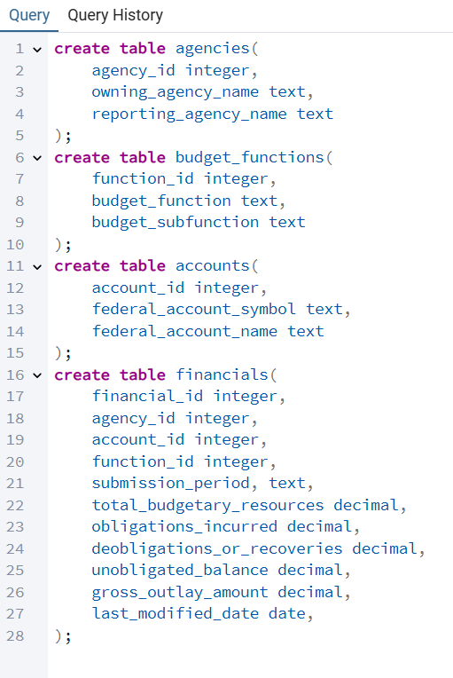

### The original Excel file required some function work in order to connect the different portions of the dataset together, primarily utilizing XLOOKUP to create the ids necessary, connected to a separate ids sheet that was not imported into pgAdmin 4.

#### Ex: =XLOOKUP(A2,ids!B:B,ids!A:A,)

#### This was the code used to create the agency id based on the id assigned to each agency in the ids table.

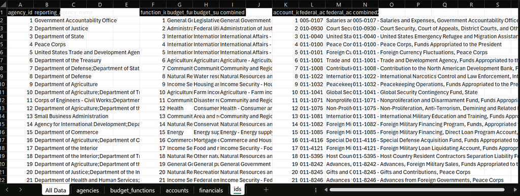

## Part 2: Importing into pgAdmin 4

### This part was very simple as the code above created the columns for me and all it took was importing through working through the GUI and all the tables were present with their respective data that I had exported as csv from Excel after having normalized it all.

## Part 3: SQL Work

#### This is the portion where I actually utilized SQL to answer specific questions about the dataset.

### Question 1: Top 10 Agencies by Obligations

#### This question is important because it allows us to see within the data which government agencies commit the most funding helps reveal where taxpayer money is being allocated and which departments are driving federal priorities. Understanding which entities are driving spending is essential in public finance for budget forecasting and auditing. Obligated funds are also funds that **must** be spent and therefore allow us to identify the agencies that are given less flexibility as they often provide essential services that need to be consistent.

#### SQL Code:

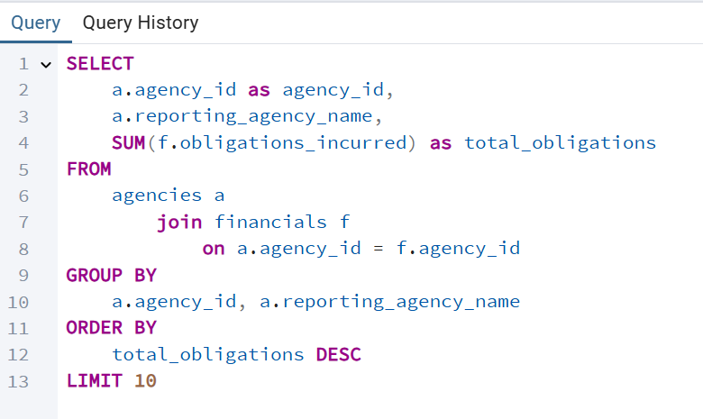

#### Result:

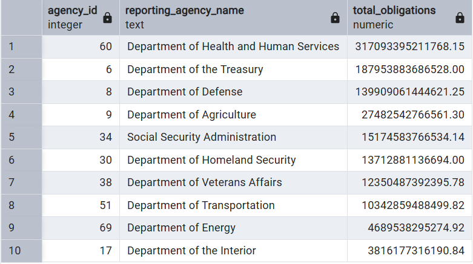

#### This result is consistent with what we would assume. The department of Health and Human Services focuses on issues that are critical to the health of the populace and therefore is affected directly by how much funding is allocated. Moving downwards the Treasury allocates funds for government operation which directly supports the rest of the departments. The Department of Defense is a (controversially) very well funded Department within the United States, overshadowing the funding allocated to similar departments in other countries by a very wide margin. The rest are all expected agencies to receive a lot of funding and are consistent with what we would expect from a query like this.

### Question 2: Functions with Over 1 Billion in Spending (USD)

#### This query reveals which core areas of government are absorbing the majority of public spending. It’s particularly useful for evaluating national priorities (for example, defense, healthcare, agriculture, etc.). These large-scale spending areas warrant greater oversight and strategic attention. It also allows the public to understand whether or not their priorities when voting are being properly addressed through financial paths.

#### SQL Code:

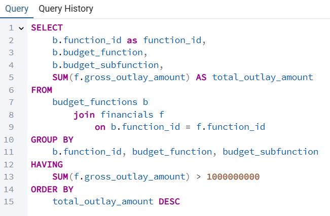

#### Result:

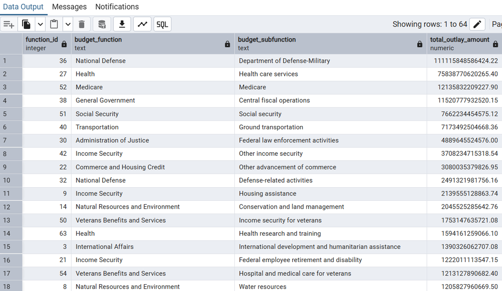

### Question 3: Row-Level Classification by Obligation Size

#### Categorizing raw data into meaningful tiers enables easier segmentation, aggregation, and visualization. It's a technique used frequently in business and government to bucket clients/entities by spend level, group transactions by risk, or classify portfolios by performance. In public data, this allows analysts to quickly isolate records of interest for audit or deeper review and is no different in this case. Here it actually makes it easier to see what proportion of the government has "high" spending and what areas are allocated less resources.

#### SQL Code:

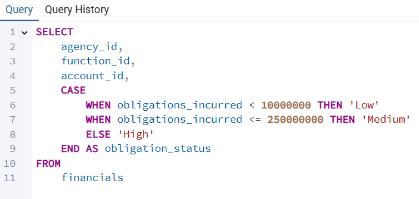

#### Result:

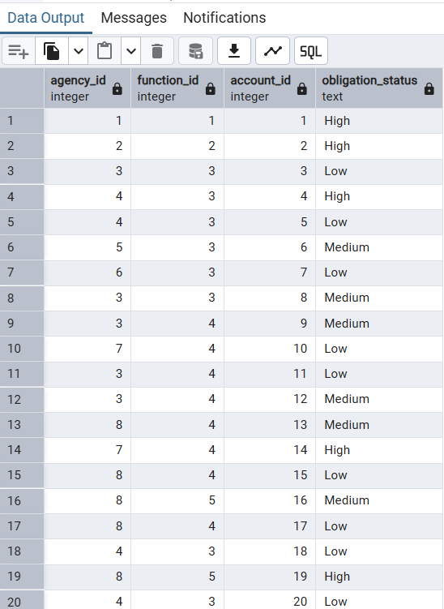

##### Note: not all rows featured

#### A notable limitation I have realized here is that this data output only features the different ids, which when looking at the Excel file it is possible to see what agency/function/subfunction it relates to however not the actual names within the result. Therefore, here is a rewritten version that includes the budget function alongside every row.

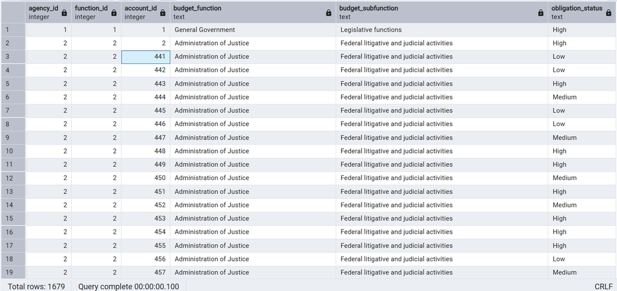

#### Although this specific data does not give any immediate insights into the function and their relation to the budget, it is a good baseline for someone to identify exactly what rows feature what level of obligation status and is good code to be used as a base for further analysis and visualization either in SQL or visualization software like Tableau.

### Question 3.5: Obligation Level Count

#### This query is an expansion on the previous one where it highlights how many rows are in each distinct category.

#### SQL Code:

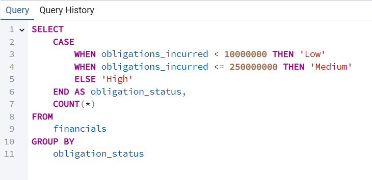

#### Result:

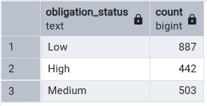

### Question 4: High Unobligated Balances Relative to Total Budget

#### This query reveals which accounts have high unobligated balances relative to their total budgets. The limit chosen was 0.25, where if more than 25% of the total budget is unobligated for a specific account, that is considered high and each row that fills this criteria is listed. The results could highlight potential underutilization of resources. When a significant portion of allocated funds is not obligated, it may suggest inefficiency, over-budgeting, bureaucratic delays, or a mismatch between planned and actual spending. Identifying these cases helps financial managers and policymakers adjust future budgets or investigate process bottlenecks. Alternatively it could also be an indicator of accounts and functions that are reserved for immense flexibility in order to address emergencies or situations as they come up.

#### SQL Code:

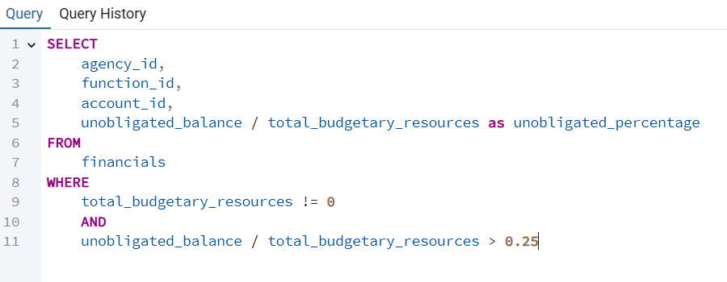

#### Result:

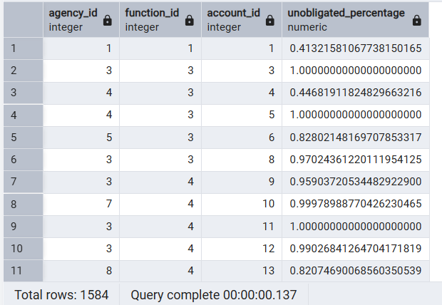

#### As witnessed here a lot of rows do feature entirely unobligated budgets which may be a sign of them being underdeveloped logistically and legally with their appropriate bills. Included in the code is also a prevention to division by 0 to catch accounts that didn't actually have anything assigned to them this period but still spent money due to carryover from previous periods. Several of these rows in future analysis could be filtered further to identify areas of government spending that lack proper development or are entirely irrelevant and could be cut to save costs if needed.

### Question 5: Gross Outlay Efficiency Ratio

#### Efficiency ratios reveal how well public funds are being used. A ratio near or above 1 means an account is executing on its budget, while lower ratios indicate lagging or underutilized programs. In financial services, similar KPIs help determine operational effectiveness and performance health. This analysis promotes transparency and also highlights the rolling nature of government spending that creates interesting results.

#### SQL Code:

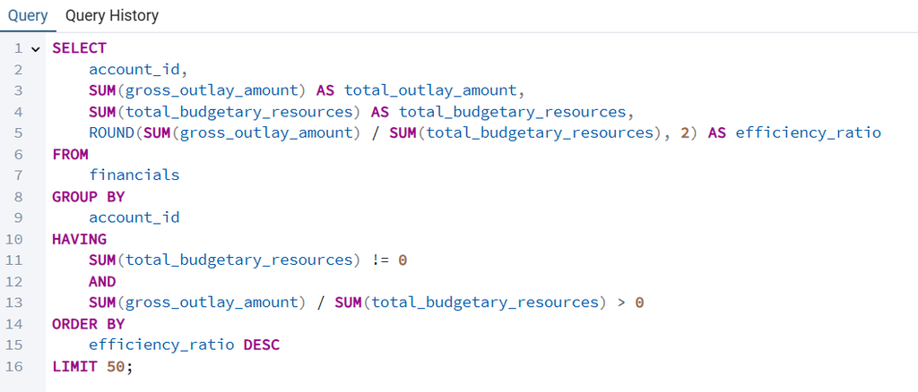

#### Result:

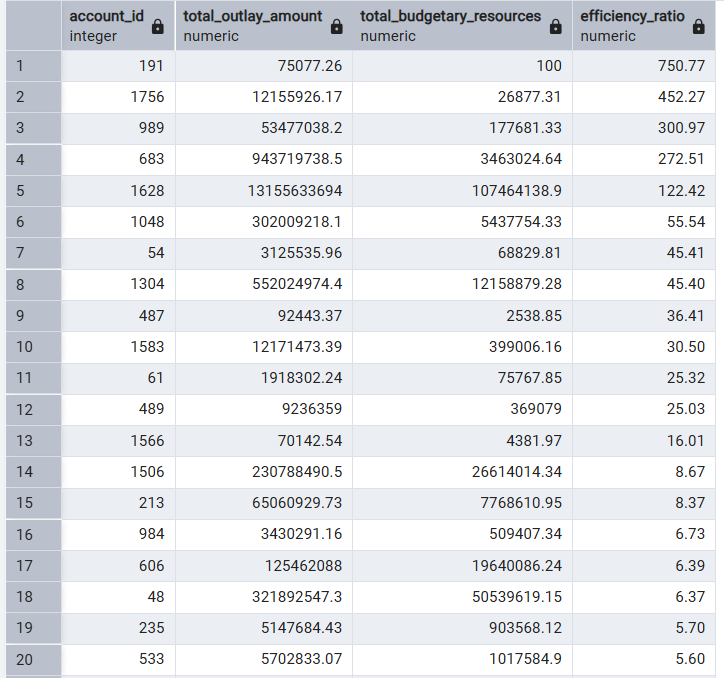

#### This table at first seemed very wrong to me, as the ratio should not be above 1. I even went through several of these accounts to see if there was an error of the data, however everything was consistent. Therefore I had to research an explanation as to why this ratio could look like this:

#### Possible Explanations:

##### Multi-year spending: An account might spend money allocated in previous years, so current outlays exceed current year's budgetary resources

##### Reimbursements and transfers: Accounts can receive additional funding mid-year that wasn't in the original budget

##### Obligation vs. outlay timing: Budget resources might be obligated in one period but the actual cash outlay happens later

##### Supplemental appropriations: Congress can provide additional funding beyond the initial budget

#### This analysis highlights how government spending is different from the pure yearly number and demonstrates the nuances within the different perspectives that can be used to examine the raw data.

### Question 6: Low-Spending Frequent Flyers

#### This query uncovers agencies that appear frequently in the financial dataset but spend relatively little per transaction or budget record. These “frequent flyers” might represent high administrative load with low financial throughput. In the context of government data, these results can flag agencies that manage many small programs or disbursements. Although not immediately a concern if analyzed more thoroughly it could highlight a potential area for consolidation or reorganization of spending approaches.

#### SQL Code:

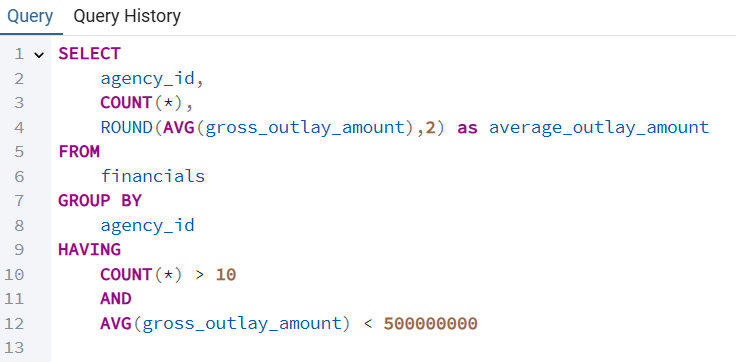

#### Result:

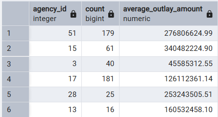

### Question 7: Efficient Small Agencies

#### This query identifies agencies that operate with relatively small total budgets (under $1 billion) but maintain high spending efficiency, defined as using at least 80% of their available resources. By calculating the ratio of total outlay amount and total budget and filtering for both low total budget and high utilization, the query highlights agencies that deliver strong output per dollar allocated. In the context of federal budgeting, this is a signal of operational discipline and effective financial management and can highlight teams doing great work within the bureaucracy of the United States government.

#### SQL Code:

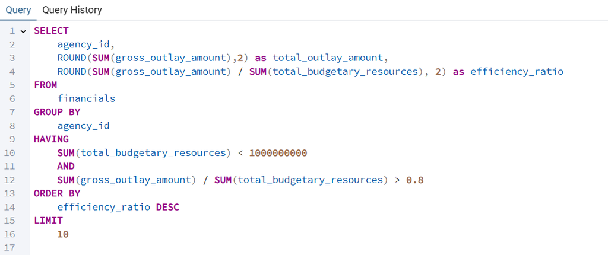

#### Result:

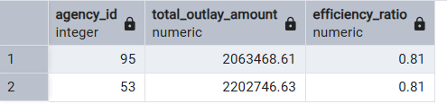

#### Funnily enough, the result only gives us two agencies that fit this criteria. This can be explained that either 80% budget usage is a high bar, or there are few agencies in general that have less than a billion in their budget, although this seems less likely due to the fact that there are plenty from our previous query that have obligations less than 10 million, meaning their unobligated percentage must be really high. Evaluating this query with different efficiency ratio benchmarks could allow the government to identify a "target" efficiency ratio that is attainable with smart financial management.

### Question 8: Overspending Subfunctions

#### Overspending against a defined budget is a red flag in any organization. This analysis helps uncover which program areas exceeded expectations or failed to control costs. It supports better policy decisions and fiscal discipline and with further analysis can be used to safeguard against similar problems in future policies.

#### SQL Code:

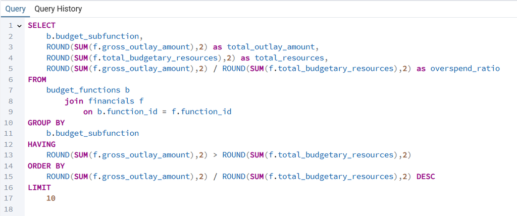

#### Result:

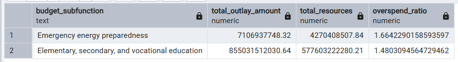

#### Our results actually suggest the opposite. With only two subfunctions showing up, it seems that most of the government is operating within its budget with limited overspending. These two categories also highlight areas that many citizens would agree are better overfunded than underfunded, especially with rising concerns of natural disasters with climate change and growing international political tensions. Education is also a valued resource for American citizens that paves the path to career growth and meaningful work.

#### Where we expected to find poor management we instead found an allocation of resources that seem to be geared towards the future and preparing instead of wasting.

## Conclusion

#### This project was created to test and practice my SQL skills through the exploration of US federal government budget allocation, utilization, and spending. I normalized the data set within Microsoft Excel and created questions about the data that could be solved through SQL queries which in turn highlighted operational differences, agency performances, and a quantification of how funds are utilized by the government across accounts and subfunctions.

#### The analysis ranged from basic SQL queries to more involved classfication logic and bucketing and in turn prompted more nuanced business questions like the ability of an agency to overspend their budget, why certain agencies were obligated to spend more and some were entirely flexible, and the differences in operational structure based on the transaction volume and average spend size.

#### During the development of this project I emphasized including critical thinking and interpretation in between writing code. Although I didn't have a set problem to solve with this data and therefore couldn't create specific suggestions as would be typical in a data analyst role, I hoped to offer insight into further paths that could be taken with specific questions that could be used to identify problems and in turn create solutions. I was using government data, however these exact same principles can very easily be applied to the private sector where I hope to work some day.

#### My dataset was limited to a single reporting period which not only limited the amount of data I actually had, but also the amount of context I could use. However, it was a good basis for my aforementioned critical thinking goals. If extended across multiple periods the dataset could be used as a basis for time-series analysis and forecasting, which in turns lends itself to visualization software like Tableau.

#### If I had to improve this project, that would be the next major step I would take. Although tables are useful for seeing the raw numbers, including visualization would instantly make the data much more readable.

#### Ultimately this project demonstrates my confidence with parts of the SQL language, but also my want and ability to extract insight and stories from data. Thank you for reading!